# Case Study: How Does a Bike-Share Navigate Speedy Success?

Jamrus Ruttanayukol

2022-03-23

This page is a record of my Google Analytic program’s capstone project. There were 2 case studies: bike-sharing company, and wellness company. I picked the former one.

Originally I wanted to do an open case study, but after looking around, I found out that there’s not enough data for my interest - where should I buy a house in Thailand. Our census data is too outdated (only up to 2010, 2014, and 2017…). With so many big things going on recently, I lost interest. Maybe after I learn more I’ll get back to it.

Anyway, Let’s jump into the project!

#### Organization

This report is organized by Data analysis steps:

- Ask
- Prepare
- Process
- Analyze
- Share
- Act

## Scenario

I’m a junior data analyst in marketing team at a Chicago bike-sharing company Cyclistic. The company wants to increase its annual membership. There are many questions to answer and they assigned me to look into how annual members and casual riders use our service differently.

For more information, please click here

## Ask

#### Question: How do annual members and casual riders use Cyclistic bikes differently?

The end goal is getting more memberships. To this end, I need to spot behavioral differences that casual riders have from members. Especially ones that’d encourage them into subscriptions.

Once I spot any difficulties the casual riders face and how annual members do their cycling, I can recommend actions to my manager, Moreno. The team can also use my insights to improve their other topics of study.

### Deliverable

As a good practice, I should have a clear business task before diving in any data:

- Identifying the possible hurdles barring casual riders to join membership.

## Prepare

For this case study, we’ll use the past 12 months trip data from Motivate International Inc. available [here](https://divvy-tripdata.s3.amazonaws.com/index.html). And before anything, I should note to myself that we must be aware of data-privacy issues and, at any circumstances, must not use customer’s personally identifiable information (i.e. credit card numbers, home address, purchase history, etc.). For a blessing, the data does not contain any personal information unless I actively look for it.

As this is an internal data, the original files will be kept in a local dedicated folder as I work in this project. Then, I’ll upload transformed data into team’s drive for other uses.

#### Data Credibility

A simple guideline for data credibility: ROCCC - Reliable, Original, Comprehensive, Current, and Cite. The data seems OK. Since this data only involve company input (and automated data), input errors should be small.

#### Data Integrity

I looked at the data and see how it’s formatted. Since this is in-house data, integrity should be good. Nonetheless, I’ll confirm further as I move to next step.

### Deliverables

The data seems to contain all information needed for this analysis. We can check bicycle type, user type, where and when they started ride and ended the ride.

Let’s check a dataset, say, 2021 March.

```r
tripdata_2103 <- read_csv('202103-divvy-tripdata.csv')
colnames(tripdata_2103)
```

```
##  [1] "ride_id"            "rideable_type"      "started_at"
##  [4] "ended_at"           "start_station_name" "start_station_id"
##  [7] "end_station_name"   "end_station_id"     "start_lat"
## [10] "start_lng"          "end_lat"            "end_lng"
## [13] "member_casual"
```

Now let’s take a quick look at the data.

```r
head(tripdata_2103)
```

```
## # A tibble: 6 x 13
##   ride_id rideable_type started_at          ended_at            start_station_n~
##   <chr>   <chr>         <dttm>              <dttm>              <chr>
## 1 CFA86D~ classic_bike  2021-03-16 08:32:30 2021-03-16 08:36:34 Humboldt Blvd &~
## 2 30D9DC~ classic_bike  2021-03-28 01:26:28 2021-03-28 01:36:55 Humboldt Blvd &~
## 3 846D87~ classic_bike  2021-03-11 21:17:29 2021-03-11 21:33:53 Shields Ave & 2~
## 4 994D05~ classic_bike  2021-03-11 13:26:42 2021-03-11 13:55:41 Winthrop Ave & ~
## 5 DF7464~ classic_bike  2021-03-21 09:09:37 2021-03-21 09:27:33 Glenwood Ave & ~
## 6 CEBA85~ classic_bike  2021-03-20 11:08:47 2021-03-20 11:29:39 Glenwood Ave & ~
## # ... with 8 more variables: start_station_id <chr>, end_station_name <chr>,
## #   end_station_id <chr>, start_lat <dbl>, start_lng <dbl>, end_lat <dbl>,
## #   end_lng <dbl>, member_casual <chr>
```

```r
tripdata_2103 %>%
  group_by(member_casual) %>%
  tally()
```

```
## # A tibble: 2 x 2
##   member_casual      n
##   <chr>          <int>
## 1 casual         84033
## 2 member        144463
```

```r
tripdata_2103 %>%
  group_by(rideable_type) %>%
  tally()
```

```
## # A tibble: 3 x 2
##   rideable_type      n
##   <chr>          <int>
## 1 classic_bike  152545
## 2 docked_bike    15657
## 3 electric_bike  60294
```

There seems to be no problem and data should be able to help us get the answers.

## Process

Now, onto the process part.

#### Chosen Tools

For this task, I’m planning to use only R. I’ve learned enough of SQL from UCDavis SQL basics specialization. I know Python is also useful but as of now I prefer to learn R. So, I hope I’ll gain understanding of R basics through this course!

#### Data Integrity Assurance

This is in-house data from the system. So, we can trust that the data integrity attributes should be good. Nonetheless, we need to check so that we can be sure of our analysis results.

Note: data integrity - the accuracy, completeness, consistency, and trustworthiness of data throughout its life cycle.

```r
trip_2022 <- rbind(trip_2201, trip_2202)
trip_2021 <- rbind(trip_2103, trip_2104, trip_2105, trip_2106, trip_2107, trip_2108, trip_2109, trip_2110, trip_2111, trip_2112)
trips <- rbind(trip_2021, trip_2022)
rm(trip_2021, trip_2022)
rm(trip_2103, trip_2104, trip_2105, trip_2106, trip_2107, trip_2108, trip_2109, trip_2110, trip_2111, trip_2112, trip_2201, trip_2202)
```

First, I’ll do a simple checks for NULL and NA.

```r
max(is.null(trips))
```

```
## [1] 0
```

```r
max(is.na(trips))
```

```
## [1] 1
```

Oh it seems there’s some NA. Let’s filter and see.

```r
head(which(is.na(trips), arr.ind=TRUE))
```

```
##        row col
## [1,] 96597   5
## [2,] 96598   5
## [3,] 96599   5
## [4,] 96600   5
## [5,] 96601   5
## [6,] 96603   5
```

OK. There’s something wrong with column 5: “start_station_name”. Let’s take a closer look.

```r
trips %>%
  filter(is.na(start_station_name)) %>%
  group_by(start_station_name, start_station_id) %>%
  tally()
```

```
## # A tibble: 4 x 3
## # Groups:   start_station_name [1]
##   start_station_name start_station_id      n
##   <chr>              <chr>             <int>
## 1 <NA>               13221                 1
## 2 <NA>               20215                 1
## 3 <NA>               WL-008                1
## 4 <NA>               <NA>             712975
```

Now it reveals that “start_station_id” also have NA. Let’s delete these rows.

```r
trips_c <- trips[complete.cases(trips),]
trips_c %>%
  filter(is.na(start_station_name)) %>%
  group_by(start_station_name, start_station_id) %>%
  tally()
```

```
## # A tibble: 0 x 3
## # Groups:   start_station_name [0]
## # ... with 3 variables: start_station_name <chr>, start_station_id <chr>,
## #   n <int>
```

Next let’s confirm that we have no more NULL or NA.

```r
max(is.null(trips_c))
```

```
## [1] 0
```

```r
max(is.na(trips_c))
```

```
## [1] 0
```

Great. Next, we should re-arrange the data a bit. Let’s add ride time and day of week columns.

First, I’ll add a column for time difference in seconds.

```r
trip_length <- difftime(as.POSIXct(trips_c$ended_at), as.POSIXct(trips_c$started_at), unit='secs')
trip_c1 <- mutate(trips_c, trip_length)
```

Next, I’ll add a column for day of week.

```r
day_of_week <- as.POSIXlt(trips_c$started_at)$wday
trip_c2 <- mutate(trip_c1, day_of_week)
rm(trip_length, day_of_week, trips_c, trip_c1)
```

Now, trip_c2 should be good for use in Analyze phase.

### Deliverable

- Documentation of any cleaning or manipulation of data –> done!

## Analyze

This is where all the fun begins! Let’s check descriptive stats.

```r
mean(trip_c2$trip_length)
```

```
## Time difference of 1297.486 secs
```

```r
max(trip_c2$trip_length)
```

```
## Time difference of 3356649 secs
```

Certainly someone occupied their bike over 900 hours! Let’s see how many rows are with over 100 hours and what can I see from it.

```r
filter(trip_c2, trip_length > 360000)
```

```
## # A tibble: 407 x 15
##    ride_id          rideable_type started_at          ended_at
##    <chr>            <chr>         <dttm>              <dttm>
##  1 CC6D7C07DF55006B docked_bike   2021-03-27 18:46:55 2021-04-04 16:47:51
##  2 B565F3DB8A064108 docked_bike   2021-03-27 18:45:45 2021-04-04 16:47:58
##  3 2CE0E235CD608CD6 docked_bike   2021-03-04 06:29:39 2021-03-12 08:11:12
##  4 8132866080BCB368 docked_bike   2021-03-27 13:06:02 2021-04-01 14:24:53
##  5 2A4B5E818D855F78 docked_bike   2021-03-25 10:57:10 2021-03-29 21:03:00
##  6 CCC052F50EDF3908 docked_bike   2021-03-09 21:50:04 2021-03-14 15:50:31
##  7 53583F66F8F545C9 docked_bike   2021-03-08 15:21:19 2021-03-13 08:47:35
##  8 C26113EB6F15B90F docked_bike   2021-03-21 03:01:27 2021-03-26 16:25:50
##  9 83F37001BA988B9F docked_bike   2021-03-20 23:58:11 2021-03-29 17:01:59
## 10 FE8E0FFFFBE57FFE docked_bike   2021-03-13 18:06:47 2021-03-20 13:39:11
## # ... with 397 more rows, and 11 more variables: start_station_name <chr>,
## #   start_station_id <chr>, end_station_name <chr>, end_station_id <chr>,
## #   start_lat <dbl>, start_lng <dbl>, end_lat <dbl>, end_lng <dbl>,
## #   member_casual <chr>, trip_length <drtn>, day_of_week <int>
```

Next, let’s see day of week modes.

```r
trip_c2 %>%
  group_by(day_of_week) %>%
  tally()
```

```
## # A tibble: 7 x 2
##   day_of_week      n
##         <int>  <int>
## 1           0 720826
## 2           1 590034
## 3           2 613854
## 4           3 622959
## 5           4 602766
## 6           5 657547
## 7           6 823117
```

Most rides start on Saturday, but overall data is pretty well distributed. Now let’s go deeper. Firstly, average trip length for each user type.

```r
trip_c2 %>%
  group_by(member_casual) %>%
  summarize(mean(trip_length))
```

```
## # A tibble: 2 x 2
##   member_casual `mean(trip_length)`
##   <chr>         <drtn>
## 1 casual        1944.1643 secs
## 2 member         782.6001 secs
```

That’s surprising. Casual users do spend more time on their rides. Let’s dig more onto each day of week.

```r
trip_c2 %>%
  filter(member_casual == 'casual') %>%
  group_by(day_of_week) %>%
  summarize(mean(trip_length),n(),median(trip_length),max(trip_length),min(trip_length))
```

```
## # A tibble: 7 x 6
##   day_of_week `mean(trip_length)`  `n()` `median(trip_length)` `max(trip_lengt~`
##         <int> <drtn>               <int> <drtn>                <drtn>
## 1           0 2253.069 secs       405097 1167 secs             3235296 secs
## 2           1 1953.484 secs       231584 1000 secs             1900899 secs
## 3           2 1719.922 secs       216100  881 secs             2335375 secs
## 4           3 1694.881 secs       218927  860 secs             2337785 secs
## 5           4 1688.602 secs       224485  846 secs             2946429 secs
## 6           5 1843.157 secs       290132  929 secs             3341501 secs
## 7           6 2077.956 secs       466500 1108 secs             3356649 secs
## # ... with 1 more variable: `min(trip_length)` <drtn>
```

Let’s look at member users data as well.

```r
trip_c2 %>%
  filter(member_casual == 'member') %>%
  group_by(day_of_week) %>%
  summarize(mean(trip_length),n(),median(trip_length),max(trip_length),min(trip_length))
```

```
## # A tibble: 7 x 6
##   day_of_week `mean(trip_length)`  `n()` `median(trip_length)` `max(trip_lengt~`
##         <int> <drtn>               <int> <drtn>                <drtn>
## 1           0 902.6447 secs       315729 654 secs              89183 secs
## 2           1 755.0917 secs       358450 552 secs              86499 secs
## 3           2 734.3031 secs       397754 547 secs              88022 secs
## 4           3 738.7609 secs       404032 553 secs              87634 secs
## 5           4 734.2473 secs       378281 548 secs              88005 secs
## 6           5 762.3241 secs       367415 567 secs              89034 secs
## 7           6 879.6851 secs       356617 648 secs              89738 secs
## # ... with 1 more variable: `min(trip_length)` <drtn>
```

Strange. Both user types seems to have negative or zero trip length values. Did I miss something in the data?

```r
filter(trip_c2, trip_length <= 0)
```

```
## # A tibble: 199 x 15
##    ride_id          rideable_type started_at          ended_at
##    <chr>            <chr>         <dttm>              <dttm>
##  1 F79335E3A77A57B5 electric_bike 2021-03-29 15:41:21 2021-03-29 15:41:20
##  2 48013AE627711DB0 classic_bike  2021-03-24 19:32:44 2021-03-24 19:32:44
##  3 650661065904F60B classic_bike  2021-03-05 08:10:51 2021-03-05 08:10:51
##  4 5D2797A8FFA71B49 classic_bike  2021-03-13 18:02:58 2021-03-13 18:02:57
##  5 6DF29AE1FBE4AEF4 docked_bike   2021-04-25 17:37:07 2021-04-25 17:37:07
##  6 BC53ECCBC76278FD classic_bike  2021-04-07 16:11:33 2021-04-07 16:11:26
##  7 EDB619E8797A7368 electric_bike 2021-04-23 11:30:54 2021-04-23 11:30:54
##  8 4CE43CE32F29966A classic_bike  2021-04-27 17:29:35 2021-04-27 17:29:35
##  9 6E81034B446FC2FD electric_bike 2021-04-23 09:43:39 2021-04-23 09:43:29
## 10 318DD838369AEA61 classic_bike  2021-04-30 10:56:32 2021-04-30 10:56:30
## # ... with 189 more rows, and 11 more variables: start_station_name <chr>,
## #   start_station_id <chr>, end_station_name <chr>, end_station_id <chr>,
## #   start_lat <dbl>, start_lng <dbl>, end_lat <dbl>, end_lng <dbl>,
## #   member_casual <chr>, trip_length <drtn>, day_of_week <int>
```

Not many. Let’s take them out.

```r
trip_c3 <- subset(trip_c2,!(trip_length <= 0))
```

And run the stats again.

```r
trip_c3 %>%
  filter(member_casual == 'casual') %>%
  group_by(day_of_week) %>%
  summarize(mean(trip_length),n(),median(trip_length),max(trip_length),min(trip_length))
```

```
## # A tibble: 7 x 6
##   day_of_week `mean(trip_length)`  `n()` `median(trip_length)` `max(trip_lengt~`
##         <int> <drtn>               <int> <drtn>                <drtn>
## 1           0 2253.386 secs       405062 1168 secs             3235296 secs
## 2           1 1953.526 secs       231579 1000 secs             1900899 secs
## 3           2 1719.963 secs       216095  881 secs             2335375 secs
## 4           3 1694.920 secs       218922  860 secs             2337785 secs
## 5           4 1688.633 secs       224481  846 secs             2946429 secs
## 6           5 1843.228 secs       290121  929 secs             3341501 secs
## 7           6 2078.014 secs       466487 1108 secs             3356649 secs
## # ... with 1 more variable: `min(trip_length)` <drtn>
```

```r
trip_c3 %>%
  filter(member_casual == 'member') %>%
  group_by(day_of_week) %>%
  summarize(mean(trip_length),n(),median(trip_length),max(trip_length),min(trip_length))
```

```
## # A tibble: 7 x 6
##   day_of_week `mean(trip_length)`  `n()` `median(trip_length)` `max(trip_lengt~`
##         <int> <drtn>               <int> <drtn>                <drtn>
## 1           0 902.8666 secs       315701 654 secs              89183 secs
## 2           1 755.1151 secs       358439 552 secs              86499 secs
## 3           2 734.3252 secs       397742 547 secs              88022 secs
## 4           3 738.8411 secs       403992 553 secs              87634 secs
## 5           4 734.2611 secs       378274 548 secs              88005 secs
## 6           5 762.3497 secs       367403 567 secs              89034 secs
## 7           6 879.7124 secs       356606 648 secs              89738 secs
## # ... with 1 more variable: `min(trip_length)` <drtn>
```

Doesn’t seem that helps with anything. Anyway, we can see more that casual users median and max trip time are higher than member users.

Apparently, many casual members ride a bike on a daily basis. Marketing team could look further into this to get them subscribed!

## Share

Now I was just reminded that I will be presenting the findings to the executive team. Let’s make some viz to support my 3 findings. But first, I need to format my day of week correctly!

```r
trip_c3$day_of_week <- recode(as.character(trip_c3$day_of_week),
       "0"="Sunday",
       "1"="Monday",
       "2"="Tuesday",
       "3"="Wednesday",
       "4"="Thursday",
       "5"="Friday",
       "6"="Saturday")
trip_c3$day_of_week <- ordered(trip_c3$day_of_week, levels = c('Sunday', 'Monday', 'Tuesday', 'Wednesday', 'Thursday', 'Friday', 'Saturday'))
```

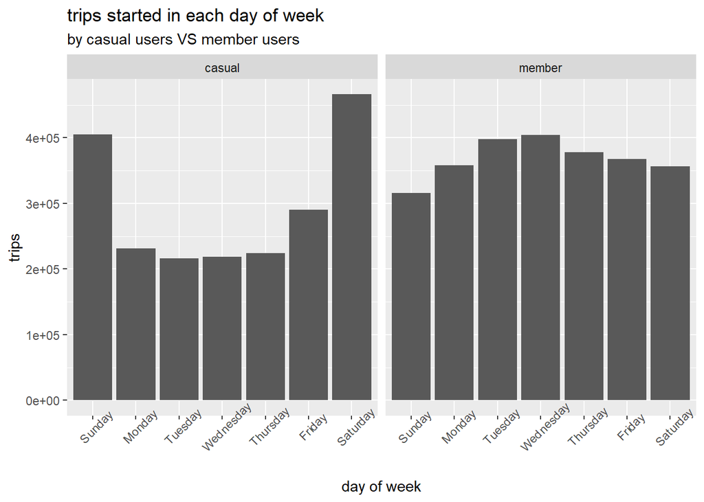

```r
ggplot(data=trip_c3) + geom_bar(mapping=aes(x=day_of_week)) +
  facet_wrap('member_casual') +
  labs(title = 'trips started in each day of week', subtitle = 'by casual users VS member users', x = 'day of week', y = 'trips' ) + theme(axis.text.x = element_text(angle = 45))
```

That’s one viz down. Next up, the average trip time.

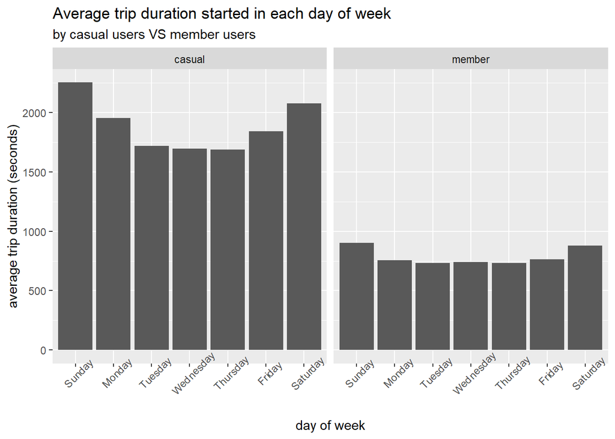

```r
ggplot(data=trip_c3) + stat_summary(aes(x = day_of_week, y = trip_length), fun = "mean", geom = "bar") +
  facet_wrap('member_casual') +
  labs(title = 'Average trip duration started in each day of week', subtitle = 'by casual users VS member users', x = 'day of week', y = 'average trip duration (seconds)' ) + theme(axis.text.x = element_text(angle = 45))
```

That’s another one done! Let’s make the viz for the last one.

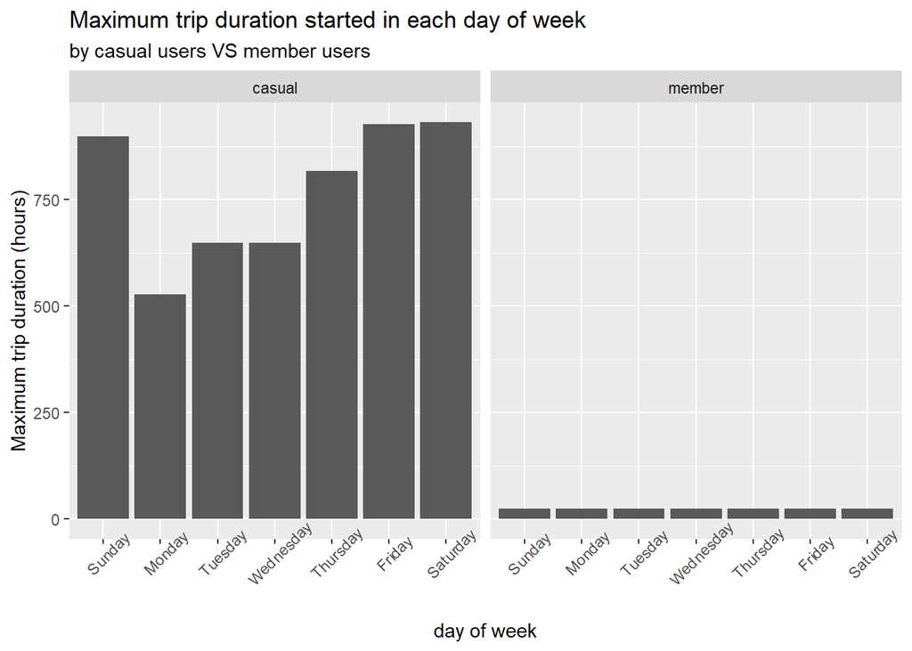

```r
ggplot(data=trip_c3) + stat_summary(aes(x = day_of_week, y = trip_length/3600), fun = "max", geom = "bar") +
  facet_wrap('member_casual') +
  labs(title = 'Maximum trip duration started in each day of week', subtitle = 'by casual users VS member users', x = 'day of week', y = 'Maximum trip duration (hours)' ) + theme(axis.text.x = element_text(angle = 45))
```

Now that’s all the viz created for all 3 findings. In actual work I’d move over to PowerPoint to make presentation with these visualizations (and some stats descriptions).

## Act

My top three recommendations would be:

- Highlight each users spending and how could they save by subscribing.
- Create offer to recommend how users can ride a bike to do their daily tasks
- Follow up with users who took bikes for over a month